# Классификация комментариев к описаниям товаров интернет-магазина

Интернет-магазин стал популярным способом продажи товаров. На таких площадках для каждого товара создаётся его карточка, которая содержит изображение товара, его описание, характеристики, информацию о преимуществах и недостатках, цену и, возможно, другую полезную информацию.

Для улучшения качества описаний товаров и привлечения к ним ещё большего внимания интернет-магазин может предоставить клиентам возможность редактировать и дополнять описания товаров, комментировать исправления других покупателей. Такой сервис будет способствовать диалогу и обмену идеями между пользователями: это поможет не только улучшить качество описаний товаров, но, потенциально, сможет привлечь ещё большее количество покупателей.

Редактирование описаний товаров и комментирование должно быть направлено на предоставление точной, ёмкой и привлекательной информации о товаре, чтобы помочь покупателям принять решение о покупке. Однако не все комментарии клиентов могут оказаться конструктивными. Токсичные комментарии могут вызвать негативные эмоции у других пользователей и нанести вред репутации интернет-магазина.

Токсичные комментарии — это комментарии, содержащие оскорбительные высказывания, угрожающую или ненормативную лексику, призывы к экстремизму и насилию, а также другие формы негативного контента. Такие комментарии могут создавать небезопасную и нездоровую среду на онлайн-платформе.

Чтобы создать и поддерживать комфортную среду для пользователей, нужно бороться с токсичными комментариями. Их необходимо обнаруживать и отправлять на модерацию. Задача обнаружения оскорбительного (токсичного) контента — это задача обработки естественного языка, которая заключается в автоматическом определении текстов, содержащих негативный контент. Одним из подходов в решении задачи является использование алгоритмов машинного обучения, которые обучаются на больших наборах данных, содержащих тексты как с позитивным, так и с негативным контентом. А уже затем используются для автоматического определения наличия токсичного контента в сообщениях пользователей.

В нашем распоряжении находятся размеченные данные, содержащие тексты комментариев с разметкой об их токсичности.

Для того чтобы автоматически определять наличие токсичного контента в комментариях пользователей, нужно построить модель, которая сможет проанализировать данные о токсичности комментариев и наиболее точным образом определит, является ли комментарий токсичным или нет.

**Цель проекта:** построить модель, классифицирующую комментарии на позитивные и негативные.

**Задачи проекта:**

- выполнить предобработку данных;
- разбить данные на тренировочную и валидационную выборки (при необходимости выделить тестовую выборку);
- выбрать алгоритмы и построить модели;
- учесть дисбаланс классов (при необходимости);
- выбрать метрики качества моделей и оценить их значения.

# Содержание

Внимание! Для корректной работы кода в ячейках рекомендуется предварительно установить следующие библиотеки:

```python
import sys
!{sys.executable} -m pip install spacy -q
!{sys.executable} -m spacy download en_core_web_sm -q
```

[output not shown]

```python
!pip install catboost -q
```

```python
!pip install lightgbm -q
```

## Обзор данных

### Импорт библиотек и предварительные настройки

```python
import pandas as pd
import matplotlib.pyplot as plt
import numpy as np
import seaborn as sns
import os
import re
import spacy
import nltk

from sklearn.feature_extraction.text import TfidfVectorizer
from nltk.corpus import stopwords

from sklearn.model_selection import train_test_split, RandomizedSearchCV
from sklearn.pipeline import Pipeline
from sklearn.dummy import DummyClassifier
from sklearn.linear_model import (LogisticRegression,
                                  SGDClassifier,
                                  RidgeClassifier)
from sklearn.tree import DecisionTreeClassifier
from sklearn.svm import LinearSVC
from catboost import CatBoostClassifier
from lightgbm import LGBMClassifier
from sklearn.metrics import f1_score

nltk.download('stopwords')

pd.set_option('display.max_columns', None)
np.set_printoptions(threshold=sys.maxsize)

RANDOM_STATE = 1
```

### Чтение файла и загрузка данных

Все данные хранятся в одном файле.  
Файл данных `toxic_comments.csv` имеет формат `CSV`.

```python
pth1 = r'C:\Users\Георгий\Documents\DS_projects\toxic_comments.csv'
pth2 = '/datasets/toxic_comments.csv'
pth3 = '/content/toxic_comments.csv'

if os.path.exists(pth1):
    data = pd.read_csv(pth1)
elif os.path.exists(pth2):
    data = pd.read_csv(pth2)
elif os.path.exists(pth3):
    data = pd.read_csv(pth3)
else:
    print('Something is wrong')
```

Убедимся, что данные подгрузились верно, без ошибок.

Для этого выведем первые 5 строк и последние 5 строк набора данных.

```python
data.head()
```

|  | Unnamed: 0 | text | toxic |
| --- | --- | --- | --- |
| 0 | 0 | Explanation\nWhy the edits made under my usern... | 0 |
| 1 | 1 | D'aww! He matches this background colour I'm s... | 0 |
| 2 | 2 | Hey man, I'm really not trying to edit war. It... | 0 |
| 3 | 3 | "\nMore\nI can't make any real suggestions on ... | 0 |
| 4 | 4 | You, sir, are my hero. Any chance you remember... | 0 |

```python
data.tail()
```

|  | Unnamed: 0 | text | toxic |
| --- | --- | --- | --- |
| 159287 | 159446 | ":::::And for the second time of asking, when ... | 0 |
| 159288 | 159447 | You should be ashamed of yourself \n\nThat is ... | 0 |
| 159289 | 159448 | Spitzer \n\nUmm, theres no actual article for ... | 0 |
| 159290 | 159449 | And it looks like it was actually you who put ... | 0 |
| 159291 | 159450 | "\nAnd ... I really don't think you understand... | 0 |

### Общая характеристика набора данных

Размер набора данных:

```python
data.shape
```

```
(159292, 3)
```

Количество элементов данных:

```python
data.size
```

```
477876
```

Типы данных набора данных:

```python
data.dtypes
```

```
Unnamed: 0     int64
text          object
toxic          int64
dtype: object
```

Пропущенные значения в данных:

```python
data.isna().sum()
```

```
Unnamed: 0    0
text          0
toxic         0
dtype: int64
```

## Понимание данных

> **Текст комментария к описанию товара** — это текст, который пользователи могут оставлять на странице товара в интернет-магазине.

Комментарии могут содержать отзывы пользователей, их вопросы, рекомендации, а также другую информацию. Всё это поможет другим покупателям быть более информированными при выборе товара и поможет им принять более взвешенное решение о его покупке. Комментарии могут быть как позитивными, так и негативными.

`text` — текст комментария к описанию товара  
Признак является категориальным, номинальным.  
Шкала измерения признака: номинальная шкала.

**Факт того, является ли комментарий токсичным**, зависит от его содержания и от того, как он воспринимается другими пользователями. Комментарий может быть токсичным, если он содержит оскорбления, угрозы, ненормативную лексику или другой негативный контент.

`toxic` — факт того, является ли комментарий токсичным — целевой признак  
Признак является категориальным, бинарным.  
Шкала измерения признака: дихотомическая шкала.

## Предобработка данных

Признак `Unnamed: 0` был ошибочно оставлен при сохранении набора данных. Для построения модели он не представляет ценности. Удалим его.

```python
data.drop(['Unnamed: 0'], axis=1, inplace=True)
```

```python
data.columns
```

```
Index(['text', 'toxic'], dtype='object')
```

### Удаление небуквенных символов и токенизация

Разобъём тексты на слова. Удалим из текстов лишние символы: знаки пунктуации, числовые и спецсимволы. Оставим только прописные и строчные латинские буквы.

```python
def clear_text(text):
    '''
    Функция удаляет символы, если они не являются символами
    латинского алфавита верхнего и нижнего регистров, и
    сокращает несколько идущих подряд пробелов до одного.

    Принимает необработанную строку текста.
    Возвращает строку, содержащую только символы латинского
    алфавита верхнего и нижнего регистра и одиночные пробелы.
    '''

    # Замена символов, не являющихся буквами латинского алфавита,
    # на пробелы.
    text = re.sub(r'[^a-zA-Z]', ' ', text)

    # Разделение текста на слова (используя пробелы в качестве
    # разделителя) и последующее соединение слов в строку
    # с помощью одного пробела.
    text = " ".join(text.split())

    return text
```

```python
data['text'] = data['text'].apply(lambda x: clear_text(x))
```

```python
data['text']
```

```
0         Explanation Why the edits made under my userna...
1         D aww He matches this background colour I m se...
2         Hey man I m really not trying to edit war It s...
3         More I can t make any real suggestions on impr...
4         You sir are my hero Any chance you remember wh...
                                ...
159287    And for the second time of asking when your vi...
159288    You should be ashamed of yourself That is a ho...
159289    Spitzer Umm theres no actual article for prost...
159290    And it looks like it was actually you who put ...
159291    And I really don t think you understand I came...
Name: text, Length: 159292, dtype: object
```

### Лемматизация

Разобъём тексты на слова и приведём слова к их базовой форме — лемме.

```python
# Загрузка языковой модели.
nlp = spacy.load('en_core_web_sm', disable=['parser', 'ner'])
```

```python
def lemmatize(text):
    '''
    Функция лемматизирует входной текст,
    преобразуя каждое слово в его базовую или словарную форму.

    Принимает строку текста, которую необходимо лемматизировать.
    Возвращает строку лемматизированного текста.
    '''

    # Токенизация и последующая лемматизация строки текста.
    text = nlp(text)
    text = " ".join([token.lemma_ for token in text])

    return text
```

```python
%%time

data['text'] = data['text'].apply(lambda x: lemmatize(x))
```

```
CPU times: user 19min 20s, sys: 3.54 s, total: 19min 24s
Wall time: 19min 40s
```

```python
data['text']
```

```
0         Explanation why the edit make under my usernam...
1         d aww he match this background colour I m seem...
2         hey man I m really not try to edit war it s ju...
3         More I can t make any real suggestion on impro...
4         you sir be my hero any chance you remember wha...
                                ...
159287    and for the second time of ask when your view ...
159288    you should be ashamed of yourself that be a ho...
159289    Spitzer Umm there s no actual article for pros...
159290    and it look like it be actually you who put on...
159291    and I really don t think you understand I come...
Name: text, Length: 159292, dtype: object
```

### Обработка пропусков

```python
sum(data['text'] == '')
```

```
11
```

Записей с пропущенными значениями — всего 11. Вероятно, это были либо пустые сообщения, либо короткие и не содержательные.

```python
data.shape
```

```
(159292, 2)
```

Удалим записи с пропущенными значениями.

```python
data.drop(data[data['text'] == ''].index, axis=0, inplace=True)
data.shape
```

```
(159281, 2)
```

### Обработка дубликатов

```python
data[data.duplicated(keep=False)].head(6)
```

|  | text | toxic |
| --- | --- | --- |
| 165 | July UTC P S Feel free to leave a message on m... | 0 |
| 177 | may | 0 |
| 235 | please stop add nonsense to Wikipedia it be co... | 0 |
| 351 | Future Perfect at Sunrise | 0 |
| 522 | apparently other editor agree that the edit I ... | 0 |
| 568 | whoever write the Plot I feel terrible for who... | 0 |

```python
data.duplicated().sum()
```

```
1250
```

Полных дубликатов в наборе данных — 1250.

```python
data['text'].duplicated().sum()
```

```
1277
```

```python
data.shape
```

```
(159281, 2)
```

```python
data.drop_duplicates(subset='text', keep=False, inplace=True)
data.shape
```

```
(157285, 2)
```

```python
data['text'].duplicated().sum()
```

```
0
```

## Построение моделей

### Подготовка данных для обучения

#### Разделение данных на выборки

Выделим из данных целевой признак `toxic`.

```python
features = data['text']
target = data['toxic']
```

Поскольку отдельной тестовой выборки нет и большой объём данных позволяет обучать алгоритмы без отдельной кросс-валидации, разделим данные на тренировочную, валидационную и тестовую выборки в отношении 3 : 1 : 1. Таким образом, размеры валидационной и тестовой выборок будут равными.

```python
features_other, features_test, target_other, target_test = train_test_split(
    features, target, test_size=0.2, random_state=RANDOM_STATE)
```

```python
features_train, features_valid, target_train, target_valid = train_test_split(
    features_other, target_other, test_size=0.25, random_state=RANDOM_STATE)
```

#### Векторизация

Для векторизации текстов будем использовать метод TF-IDF. В процессе векторизации не будем учитывать стоп-слова из списка стоп-слов английского языка.

```python
stop_words = list(stopwords.words('english'))
```

Для обучения линейных алгоритмов и алгоритмов на основе метода опорных векторов будем дополнительно использовать N-граммы: биграммы и триграммы. Алгоритмы, основанные на использовании деревьев решений, будем изучать без N-грамм.

### Обучение моделей

Поскольку целевой признак `toxic` — категориальный (бинарный), следовательно, необходимо решить задачу бинарной классификации.

Зафиксируем псевдослучайность для алгоритмов обучения.

Оценку качества обученных моделей будем проводить, рассчитывая значение F1-меры. Обученная модель будет считаться выполняющей качественный прогноз, если значение F1-меры будет составлять не менее 0,75.

Для того чтобы получить максимально высокое качество предсказания, нужно перебрать в алгоритмах обучения разные значения гиперпараметров.

Наилучшими гиперпараметрами для моделей классификации признаем те, при которых получится максимальное значение F1-меры обученной модели, оценённой на валидационной выборке.

В данных наблюдается дисбаланс классов признака `toxic`. Поэтому необходимо при обучении алгоритмов использовать взвешивание классов.

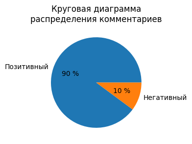

```python
labels = 'Позитивный', 'Негативный'
plt.figure(figsize=(3, 3))
plt.pie(data['toxic'].value_counts(), labels=labels, autopct='%.0f %%')
plt.title('Круговая диаграмма\nраспределения комментариев')
plt.show()
```

#### Простая модель

```python
%%time

pipeliner = Pipeline([
    ('vectorizer', TfidfVectorizer(stop_words=stop_words, dtype=np.float32)),
    ('model', DummyClassifier(strategy="constant", constant=1))
])

pipeliner.fit(features_train, target_train)

predictions = pipeliner.predict(features_valid)

print('Простая модель, предсказывающая значение меньшего класса')
print('\nF1 =', round(f1_score(predictions, target_valid), 3))
```

```
Простая модель, предсказывающая значение меньшего класса

F1 = 0.183
CPU times: user 7.9 s, sys: 167 ms, total: 8.07 s
Wall time: 8.21 s
```

#### Логистическая регрессия

```python
%%time

pipeliner = Pipeline([
    ('vectorizer', TfidfVectorizer(stop_words=stop_words, dtype=np.float32,
                                   ngram_range=(1, 3))),
    ('model', LogisticRegression(solver='liblinear', class_weight='balanced',
                                 random_state=RANDOM_STATE))
])

parameters = {'model__tol': [10**n for n in range(-1, -4, -1)],
              'model__C': [10**n for n in range(4, -6, -1)],
              'model__max_iter': [10**n for n in range(2, 6, 1)]}

lr = RandomizedSearchCV(pipeliner, param_distributions=parameters, n_iter=10,
                        scoring='f1', random_state=RANDOM_STATE, n_jobs=-1,
                        error_score='raise')

lr.fit(features_train, target_train)

predictions = lr.predict(features_valid)

print('Модель логистической регрессии')
print('\nF1 =', round(f1_score(predictions, target_valid), 3))
print('\nПараметры наилучшей модели:',
      pd.DataFrame(lr.best_params_, index = ['']).T, '\n')
```

```
Модель логистической регрессии

F1 = 0.786

Параметры наилучшей модели:
model__tol           0.01
model__max_iter  10000.00
model__C           100.00

CPU times: user 1min 29s, sys: 15.3 s, total: 1min 44s
Wall time: 28min 16s
```

#### Классификатор с использованием гребневой регрессии

```python
%%time

pipeliner = Pipeline([
    ('vectorizer', TfidfVectorizer(stop_words=stop_words, dtype=np.float32,
                                   ngram_range=(1, 3))),
    ('model', RidgeClassifier(class_weight='balanced',
                              random_state=RANDOM_STATE))
])

parameters = {'model__tol': [10**n for n in range(1, -4, -1)],
              'model__alpha': [10**n for n in range(2, -2, -1)],
              'model__max_iter': [None]+[10**n for n in range(1, 5, 1)]}

rc = RandomizedSearchCV(pipeliner, param_distributions=parameters, n_iter=10,
                        scoring='f1', random_state=RANDOM_STATE, n_jobs=-1,
                        error_score='raise')

rc.fit(features_train, target_train)

predictions = rc.predict(features_valid)

print('Модель классификатора на основе гребневой регрессии')
print('\nF1 =', round(f1_score(predictions, target_valid), 3))
print('\nПараметры наилучшей модели:',
      pd.DataFrame(rc.best_params_, index = ['']).T, '\n')
```

```
Модель классификатора на основе гребневой регрессии

F1 = 0.756

Параметры наилучшей модели:
model__tol          0.001
model__max_iter  1000.000
model__alpha        1.000

CPU times: user 1min 13s, sys: 11.4 s, total: 1min 24s
Wall time: 26min 49s
```

#### Классификатор с использованием стохастического градиентного спуска

```python
%%time

pipeliner = Pipeline([
    ('vectorizer', TfidfVectorizer(stop_words=stop_words, dtype=np.float32,
                                   ngram_range=(1, 3))),
    ('model', SGDClassifier(class_weight='balanced', random_state=RANDOM_STATE,
                            n_jobs=-1))
])

parameters = {'model__tol': [10**n for n in range(-1, -4, -1)],
              'model__alpha': [10**n for n in range(1, -7, -1)],
              'model__eta0': [10**n for n in range(1, -4, -1)]}

sgdc = RandomizedSearchCV(pipeliner, param_distributions=parameters, n_iter=10,
                          scoring='f1', random_state=RANDOM_STATE, n_jobs=-1,
                          error_score='raise')

sgdc.fit(features_train, target_train)

predictions = sgdc.predict(features_valid)

print('Модель классификатора на основе стохастического градиентного спуска')
print('\nF1 =', round(f1_score(predictions, target_valid), 3))
print('\nПараметры наилучшей модели:',
      pd.DataFrame(sgdc.best_params_, index = ['']).T, '\n')
```

```
Модель классификатора на основе стохастического градиентного спуска

F1 = 0.788

Параметры наилучшей модели:
model__tol    0.00100
model__eta0   1.00000
model__alpha  0.00001

CPU times: user 1min 5s, sys: 5.94 s, total: 1min 11s
Wall time: 27min 2s
```

#### Метод опорных векторов

```python
%%time

pipeliner = Pipeline([
    ('vectorizer', TfidfVectorizer(stop_words=stop_words, dtype=np.float32,
                                   ngram_range=(1, 3))),
    ('model', LinearSVC(class_weight='balanced', random_state=RANDOM_STATE))
])

parameters = {'model__tol': [10**n for n in range(-1, -4, -1)],
              'model__C': [10**n for n in range(4, -6, -1)],
              'model__max_iter': [10**n for n in range(2, 6, 1)]}

lsvc = RandomizedSearchCV(pipeliner, param_distributions=parameters, n_iter=10,
                         scoring='f1', random_state=RANDOM_STATE, n_jobs=-1,
                         error_score='raise')

lsvc.fit(features_train, target_train)

predictions = lsvc.predict(features_valid)

print('Модель метода опорных векторов')
print('\nF1 =', round(f1_score(predictions, target_valid), 3))
print('\nПараметры наилучшей модели:',
      pd.DataFrame(lsvc.best_params_, index = ['']).T, '\n')
```

```
Модель метода опорных векторов

F1 = 0.784

Параметры наилучшей модели:
model__tol            0.01
model__max_iter  100000.00
model__C             10.00

CPU times: user 1min 48s, sys: 9.51 s, total: 1min 57s
Wall time: 44min 37s
```

#### Дерево решений

```python
%%time

pipeliner = Pipeline([
    ('vectorizer', TfidfVectorizer(stop_words=stop_words, dtype=np.float32,
                                   ngram_range=(1, 1))),
    ('model', DecisionTreeClassifier(class_weight='balanced',
                                     random_state=RANDOM_STATE))
])

parameters = {'model__max_depth': [None]+[n for n in range(1, 31, 1)],
              'model__min_samples_leaf': [n for n in range(1, 31, 1)],
              'model__min_samples_split': [n for n in range(2, 11, 1)]}

rfr = RandomizedSearchCV(pipeliner, param_distributions=parameters, n_iter=10,
                         scoring='f1', random_state=RANDOM_STATE, n_jobs=-1,
                         error_score='raise')

rfr.fit(features_train, target_train)

predictions = rfr.predict(features_valid)

print('Модель решающего дерева')
print('\nF1 =', round(f1_score(predictions, target_valid), 3))
print('\nПараметры наилучшей модели:',
      pd.DataFrame(rfr.best_params_, index = ['']).T, '\n')
```

```
Модель решающего дерева

F1 = 0.619

Параметры наилучшей модели:
model__min_samples_split  10
model__min_samples_leaf    7
model__max_depth          19

CPU times: user 34.9 s, sys: 3.62 s, total: 38.6 s
Wall time: 15min 26s
```

#### Градиентный бустинг на основе алгоритма LightGBM

```python
%%time

pipeliner = Pipeline([
    ('vectorizer', TfidfVectorizer(stop_words=stop_words, dtype=np.float32,
                                   ngram_range=(1, 1))),
    ('model', LGBMClassifier(class_weight='balanced', n_jobs=-1,
                             random_state=RANDOM_STATE))
])

parameters = {'model__n_estimators': [1000],
              'model__learning_rate': [0.1]}

lgbm = RandomizedSearchCV(pipeliner, param_distributions=parameters, n_iter=10,
                          scoring='f1', random_state=RANDOM_STATE, n_jobs=-1,
                          error_score='raise')

lgbm.fit(features_train, target_train)

predictions = lgbm.predict(features_valid)

print('Модель градиентного бустинга на основе алгоритма LightGBM')
print('\nF1 =', round(f1_score(predictions, target_valid), 3))
print('\nПараметры наилучшей модели:',
      pd.DataFrame(lgbm.best_params_, index = ['']).T, '\n')
```

```
[LightGBM] [Info] Number of positive: 9677, number of negative: 84694
[LightGBM] [Warning] Auto-choosing col-wise multi-threading, the overhead of testing was 13.717363 seconds.
You can set `force_col_wise=true` to remove the overhead.
[LightGBM] [Info] Total Bins 437853
[LightGBM] [Info] Number of data points in the train set: 94371, number of used features: 8341
[LightGBM] [Info] [binary:BoostFromScore]: pavg=0.500000 -> initscore=-0.000000
[LightGBM] [Info] Start training from score -0.000000
Модель градиентного бустинга на основе алгоритма LightGBM

F1 = 0.768

Параметры наилучшей модели:
model__n_estimators   1000.0
model__learning_rate     0.1

CPU times: user 9min 31s, sys: 4.21 s, total: 9min 35s
Wall time: 41min 18s
```

#### Градиентный бустинг на основе алгоритма CatBoost

Для алгоритма CatBoost не нужно проводить взвешивание классов, поскольку это приводит к значительному снижению F1 меры.

```python
%%time

pipeliner = Pipeline([
    ('vectorizer', TfidfVectorizer(stop_words=stop_words, dtype=np.float32,
                                   ngram_range=(1, 1), max_features=15000)),
    ('model', CatBoostClassifier(random_state=RANDOM_STATE, verbose=False))
])

parameters = {'model__n_estimators': [10*n+50 for n in range(10)],
              'model__learning_rate': [0.1*n+0.5 for n in range(5)]}

cb = RandomizedSearchCV(pipeliner, param_distributions=parameters, n_iter=5,
                        scoring='f1', random_state=RANDOM_STATE, n_jobs=-1,
                        error_score='raise')

cb.fit(features_train, target_train)

predictions = cb.predict(features_valid)

print('Модель градиентного бустинга на основе алгоритма CatBoost')
print('\nF1 =', round(f1_score(predictions, target_valid), 3))
print('\nПараметры наилучшей модели:',
      pd.DataFrame(cb.best_params_, index = ['']).T, '\n')
```

```
Модель градиентного бустинга на основе алгоритма CatBoost

F1 = 0.745

Параметры наилучшей модели:
model__n_estimators   120.0
model__learning_rate    0.7

CPU times: user 5min 22s, sys: 7.99 s, total: 5min 30s
Wall time: 54min 47s
```

```python
%%time

pipeliner = Pipeline([
    ('vectorizer', TfidfVectorizer(stop_words=stop_words, dtype=np.float32,
                                   ngram_range=(1, 1), max_features=15000)),
    ('model', CatBoostClassifier(random_state=RANDOM_STATE, verbose=False))
])

parameters = {'model__n_estimators': [100],
              'model__learning_rate': [0.9]}

cb = RandomizedSearchCV(pipeliner, param_distributions=parameters, n_iter=5,
                        scoring='f1', random_state=RANDOM_STATE, n_jobs=-1,
                        error_score='raise')

cb.fit(features_train, target_train)

predictions = cb.predict(features_valid)

print('Модель градиентного бустинга на основе алгоритма CatBoost')
print('\nF1 =', round(f1_score(predictions, target_valid), 3))
print('\nПараметры наилучшей модели:',
      pd.DataFrame(cb.best_params_, index = ['']).T, '\n')
```

```
Модель градиентного бустинга на основе алгоритма CatBoost

F1 = 0.754

Параметры наилучшей модели:
model__n_estimators   100.0
model__learning_rate    0.9

CPU times: user 4min 12s, sys: 3.21 s, total: 4min 15s
Wall time: 14min 16s
```

### Оценка моделей

```python
pipeliner = Pipeline([
    ('vectorizer', TfidfVectorizer(stop_words=stop_words, dtype=np.float32,
                                   ngram_range=(1, 3))),
    ('model', SGDClassifier(class_weight='balanced',
                            tol=0.001,
                            alpha=0.00001,
                            eta0=1,
                            random_state=RANDOM_STATE,
                            n_jobs=-1))
])

pipeliner.fit(features_train, target_train)

predictions = pipeliner.predict(features_test)

print('Модель классификатора на основе стохастического градиентного спуска')
print('\nF1 =', round(f1_score(predictions, target_test), 3))
```

```
Модель классификатора на основе стохастического градиентного спуска

F1 = 0.782
```

## Общий вывод

1. Для целей предсказания токсичности комментариев были построены линейные модели:
- логистическая регрессия,
- классификатор на основе стохастического градиентного спуска,
- классификатор на основе гребневой регрессии,

модели, основанные на использовании деревьев решений:

- дерево решений,
- градиентный бустинг LightGBM,
- градиентный бустинг CatBoost,

а также модели, основанные на методе опорных векторов.

[output not shown]

6. Наилучшие показатели качества демонстрирует модель классификатора, использующая алгоритм стохастического градиентного спуска с параметрами — альфа: 0,00001, начальная скорость обучения: 1, порог остановки обучения: 0,001, обученный на тексте, векторизованном методом TF-IDF, с включением в обучающий набор биграмм и триграмм.